# Project 6: Randomization and Matching

# Introduction

In this project, you will explore the question of whether college education causally affects political participation. Specifically, you will use replication data from by former Berkeley PhD students John Henderson and Sara Chatfield. Their paper is itself a replication study of by Cindy Kam and Carl Palmer. In their original 2008 study, Kam and Palmer argue that college education has no effect on later political participation, and use the propensity score matching to show that pre-college political activity drives selection into college and later political participation. Henderson and Chatfield in their 2011 paper argue that the use of the propensity score matching in this context is inappropriate because of the bias that arises from small changes in the choice of variables used to model the propensity score. They use (at that point a new method), which uses an approach similar to optimal matching to optimize Mahalanobis distance weights. Even with genetic matching, they find that balance remains elusive however, thus leaving open the question of whether education causes political participation.

You will use these data and debates to investigate the benefits and pitfalls associated with matching methods. Replication code for these papers is available online, but as you’ll see, a lot has changed in the last decade or so of data science! Throughout the assignment, use tools we introduced in lab from the and the packages. Specifically, try to use dplyr, tidyr, purrr, stringr, and ggplot instead of base R functions. While there are other matching software libraries available, MatchIt tends to be the most up to date and allows for consistent syntax.

# Data

Otherwise, we also have covariates measured for survey responses to various questions about political attitudes. We have covariates measured for the students in the baseline year, covariates for their parents in the baseline year, and covariates from follow-up surveys. . In general, post-treatment covariates will be clear from the name (i.e. student_1973Married indicates whether the student was married in the 1973 survey). Be mindful that the baseline covariates were all measured in 1965, the treatment occurred between 1965 and 1973, and the outcomes are from 1973 and beyond. We will distribute the Appendix from Henderson and Chatfield that describes the covariates they used, but please reach out with any questions if you have questions about what a particular variable means.

```r
# Load tidyverse and MatchIt
# Feel free to load other libraries as you wish
xfun::pkg_attach2(c("tidyverse",
                    "MatchIt",
                    "cobalt",
                    "gridExtra"))

# Load ypsps data
ypsps <- read_csv('data/ypsps.csv')
head(ypsps)
```

| interviewid | college | student_vote | student_meeting | student_other | student_button | student_money | student_communicate | student_demonstrate | student_community | student_ppnscal | student_PubAff | student_Newspaper | student_Radio | student_TV | student_Magazine | student_FamTalk | student_FrTalk | student_AdultTalk | student_PID | student_SPID | student_GovtOpinion | student_GovtCrook | student_GovtWaste | student_TrGovt | student_GovtSmart | student_Govt4All | student_Cynic | student_LifeWish | student_GLuck | … |
| --- | --- | --- | --- | --- | --- | --- | --- | --- | --- | --- | --- | --- | --- | --- | --- | --- | --- | --- | --- | --- | --- | --- | --- | --- | --- | --- | --- | --- | --- | --- |
| 1 | 1 | 1 | 0 | 0 | 0 | 0 | 0 | 1 | 1 | 3 | 1 | 1 | 1 | 3 | 1 | 1 | 2 | 4 | 2 | 2 | 2 | 2 | 2 | 2 | 1 | 2 | 3 | 1 | 1 | … |
| 2 | 1 | 1 | 1 | 1 | 1 | 0 | 1 | 1 | 1 | 7 | 1 | 2 | 5 | 2 | 1 | 1 | 1 | 2 | 1 | 3 | 1 | 2 | 3 | 2 | 1 | 3 | 3 | 1 | 1 | … |
| 3 | 1 | 1 | 0 | 0 | 1 | 0 | 0 | 0 | 0 | 2 | 1 | 2 | 1 | 3 | 1 | 1 | 2 | 3 | 6 | 2 | 1 | 2 | 2 | 2 | 3 | 2 | 6 | 1 | 2 | … |
| 4 | 0 | 0 | 0 | 0 | 0 | 0 | 1 | 0 | 1 | 2 | 1 | 2 | 1 | 5 | 1 | 1 | 1 | 1 | 3 | 1 | 1 | 2 | 2 | 2 | 1 | 3 | 3 | 3 | 3 | … |
| 5 | 1 | 1 | 1 | 0 | 0 | 0 | 1 | 0 | 0 | 3 | 1 | 1 | 1 | 2 | 1 | 1 | 1 | 2 | 1 | 3 | 1 | 2 | 2 | 1 | 1 | 3 | 2 | 1 | 1 | … |
| 6 | 1 | 1 | 0 | 0 | 0 | 1 | 0 | 0 | 0 | 2 | 0 | 2 | 1 | 5 | 3 | 4 | 4 | 4 | 6 | 2 | 3 | 2 | 2 | 1 | 1 | 3 | 2 | 1 | 1 | … |

# Randomization

Matching is usually used in observational studies to to approximate random assignment to treatment. But could it be useful even in randomized studies? To explore the question do the following:

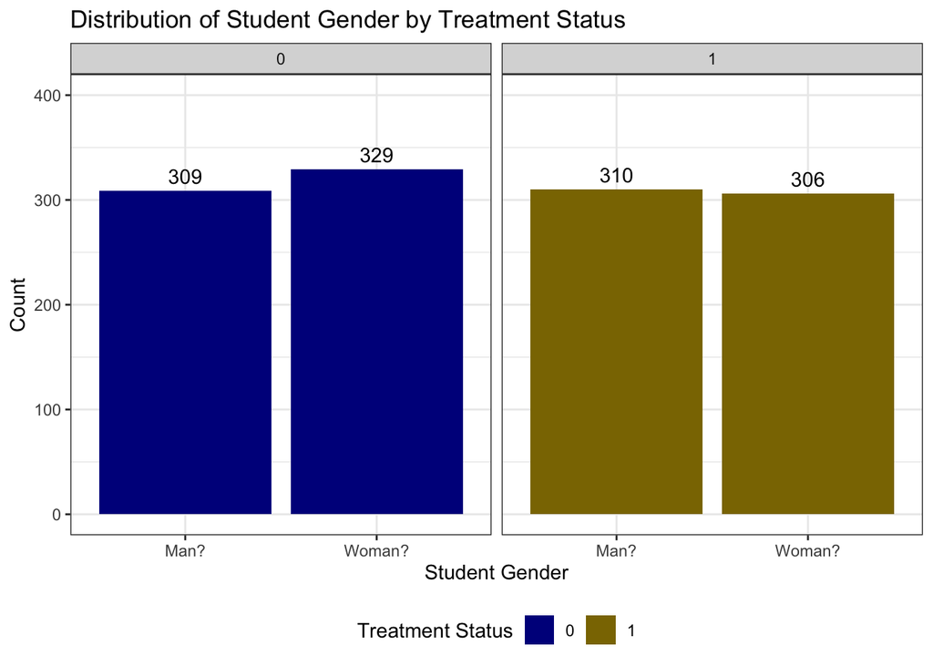

```r
set.seed(123)
# Generate a vector that randomly assigns each unit to treatment/control
dt <-
  ypsps %>%
  mutate(Y_1 = college,
         Y_0 = case_when(
           college == 1 ~ 0,
           college == 0 ~ 1),
         A_comp = as.numeric(rbernoulli(nrow(ypsps), p = 0.5)),
         Y_comp = as.numeric((A_comp & Y_1) | (!A_comp & Y_0)))

# Choose a baseline covariate (use dplyr for this)
dt <- dt %>% mutate(student_Gen_factor = as.factor(case_when(
  student_Gen == 0 ~ "Man?",
  student_Gen == 1 ~ "Woman?"
)))
dt$Y_comp_factor <- as.factor(dt$Y_comp)

# Visualize the distribution by treatment/control (ggplot)
dt %>% ggplot(aes(x = student_Gen_factor, fill = Y_comp_factor)) +
  geom_bar() +
  geom_text(stat = "count", aes(label = ..count..),
            vjust = -0.5) +
  facet_grid(cols = vars(Y_comp_factor)) +
  theme_bw() +
  theme(legend.position = "bottom") +
  scale_fill_manual(values=c("darkblue","gold4")) +
  scale_y_continuous(limits = c(0, 400)) +
  labs(x = "Student Gender",
       y = "Count",
       fill = "Treatment Status",
       title = "Distribution of Student Gender by Treatment Status")
```

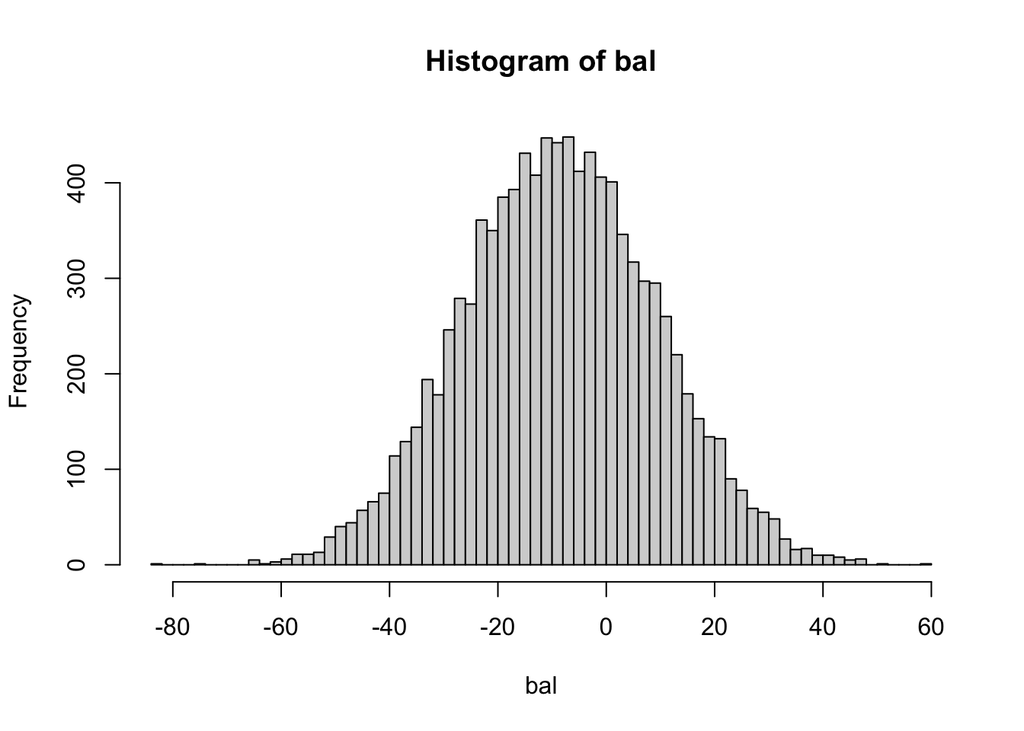

```r
# Simulate this 10,000 times (monte carlo simulation - see R Refresher for a hint)

# Create an empty list to store results
results <- vector("list", 10000)

# Loop for Monte Carlo simulation
for (i in 1:10000) {
  # Generate data for one simulation iteration
  dt.mc <- dt %>%
    mutate(Y_1 = college,
           Y_0 = case_when(
             college == 1 ~ 0,
             college == 0 ~ 1),
           A_comp = as.numeric(rbernoulli(nrow(ypsps), p = 0.5)),
           Y_comp = as.numeric((A_comp & Y_1) | (!A_comp & Y_0)))

  # Store the result of this iteration in the list
  results[[i]] <- dt.mc
}

bal <- vector("numeric", 10000)

for (i in 1:10000) {
  x <- results[[i]] %>%
    group_by(student_Gen_factor) %>%
    summarize(sum = sum(Y_comp))

  y <- x[1,2] - x[2,2]

  bal[[i]] <- y

}

bal <- unlist(bal)

hist(bal, breaks = 100)
```

```r
equalBal <- sum(bal == 0) / 10000
equalBal
```

```
## [1] 0.0198
```

## Questions

Your Answer: As shown in the last histogram of the balance across the 10,000 simulations, equal balance was rarely observed. In fact, equal balance only occurred roughly 2 percent of the time across the simulations. Independence of treatment assignment and baseline covariates does not guarantee balance of treatment assignment and baseline covariates because of chance (which is always fickle) and–in practice–non-random factors like unobserved covariates.

# Propensity Score Matching

## One Model

Select covariates that you think best represent the “true” model predicting whether a student chooses to attend college, and estimate a propensity score model to calculate the Average Treatment Effect on the Treated (ATT). Plot the balance of the top 10 (or fewer if you select fewer covariates). Report the balance of the p-scores across both the treatment and control groups, and using a threshold of standardized mean difference of p-score $\leq .1$, report the number of covariates that meet that balance threshold.

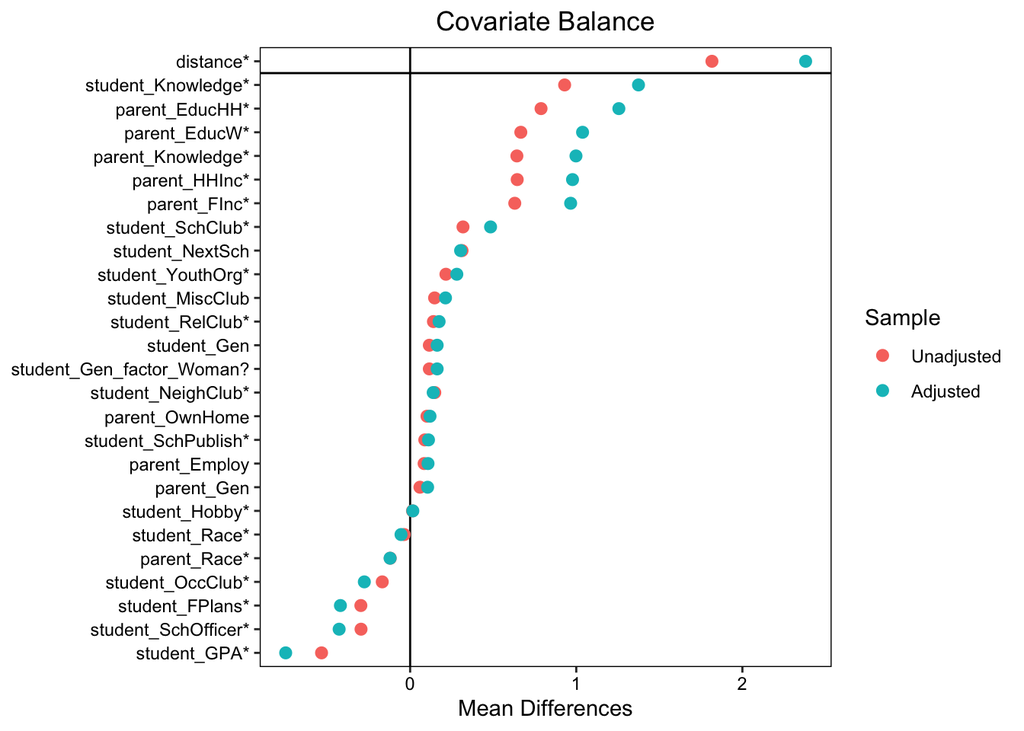

```r
# Select covariates that represent the "true" model for selection, fit model
model_ps <- matchit(formula = college ~ student_Gen_factor + student_FPlans + student_SchOfficer + student_SchPublish + student_Hobby + student_SchClub + student_OccClub + student_NeighClub + student_RelClub + student_YouthOrg + student_MiscClub + student_Knowledge + student_NextSch + student_GPA + student_Gen + student_Race + parent_Knowledge + parent_Employ + parent_EducHH + parent_EducW + parent_FInc + parent_HHInc + parent_OwnHome + parent_Gen + parent_Race,
                    data = dt,
                    method = "nearest",
                    link = "logit",
                    discard = "control",
                    replace = FALSE,
                    ratio = 2,
                    estimand = "ATT")

# Plot the balance for the top 10 covariates
love.plot(model_ps,
          var.order = "adjusted",
          stars = "std")
```

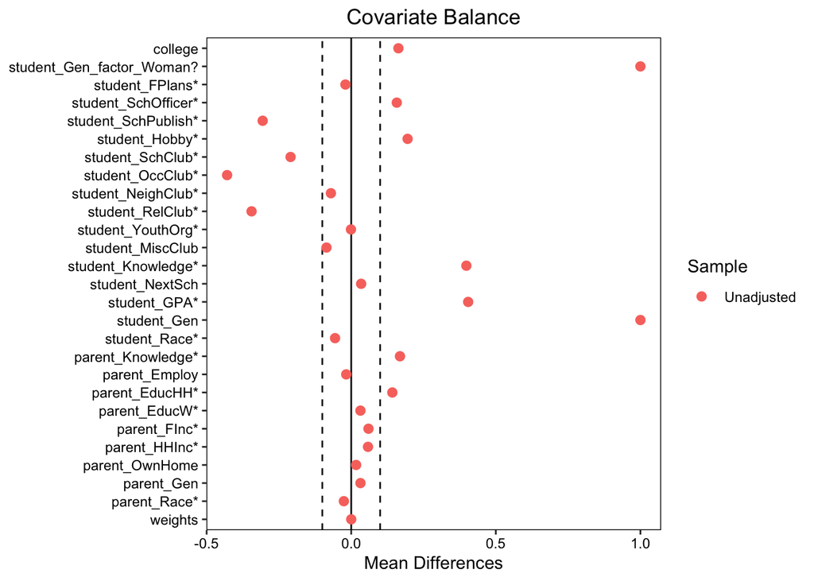

```r
# Report the overall balance and the proportion of covariates that meet the balance threshold

# Construct a matched dataset from the matchit object
dt.model_ps <- match.data(model_ps)

# Filter for treatment and selected covarariates
dt.model_ps_cov <- dt.model_ps %>%
  select(college, student_Gen_factor, student_FPlans, student_SchOfficer, student_SchPublish, student_Hobby, student_SchClub, student_OccClub, student_NeighClub, student_RelClub, student_YouthOrg, student_MiscClub, student_Knowledge, student_NextSch, student_GPA, student_Gen, student_Race, parent_Knowledge, parent_Employ, parent_EducHH, parent_EducW, parent_FInc, parent_HHInc, parent_OwnHome, parent_Gen, parent_Race, weights)

# Plot overall balance (college), treatment (student_Gen_factor_Woman?), and the selected covariates
love.plot(x = dt.model_ps_cov,
          treat = dt.model_ps_cov$student_Gen_factor,
          pscore = dt.model_ps_cov$distance,
          thresholds = .1,
          stars = "std")
```

```r
dt.model_ps_bal <- summary(model_ps) %>%
  pluck("sum.matched") %>%
  as.data.frame() %>%
  rownames_to_column(var = "variables") %>%
  rename(prop_balance_covar = "Std. Pair Dist.") %>%
  select(variables, prop_balance_covar) %>%
  summarize(prop_balance_covar = sum(prop_balance_covar > .9 & prop_balance_covar < 1.1) / length(prop_balance_covar))

# The legend says "Unadjusted" but I'm pretty sure the figure is actually plotting the adjusted balance because I've listed distance in the pscore option.

# It looks like the data is pretty unbalanced (though it's close to meeting the .1 threshold (i.e., college)), particularly when considering the treatment (which is very unbalanced). The covariates that meet the .1 balance threshold include student_FPlans, student_NeighClub, student_YouthOrg, student_MiscClub, student_NextSch, student_Race, parent_Employ, parent_educW, parent_FInc, parent_HHInc, parent_OwnHome, parent_gen, and parent_Race (13 variables).

# Model the "balanced" data
glm_prop_att <- glm(college ~ student_Gen_factor + student_FPlans + student_SchOfficer + student_SchPublish + student_Hobby + student_SchClub + student_OccClub + student_NeighClub + student_RelClub + student_YouthOrg + student_MiscClub + student_Knowledge + student_NextSch + student_GPA + student_Gen + student_Race + parent_Knowledge + parent_Employ + parent_EducHH + parent_EducW + parent_FInc + parent_HHInc + parent_OwnHome + parent_Gen + parent_Race,
                    family = binomial(link = "logit"),
                    data = dt.model_ps_cov,
                    weights = weights)

# view summary of results
glm_prop_att <- summary(glm_prop_att)
glm_prop_att
```

```
##
## Call:
## glm(formula = college ~ student_Gen_factor + student_FPlans +
##     student_SchOfficer + student_SchPublish + student_Hobby +
##     student_SchClub + student_OccClub + student_NeighClub + student_RelClub +
##     student_YouthOrg + student_MiscClub + student_Knowledge +
##     student_NextSch + student_GPA + student_Gen + student_Race +
##     parent_Knowledge + parent_Employ + parent_EducHH + parent_EducW +
##     parent_FInc + parent_HHInc + parent_OwnHome + parent_Gen +
##     parent_Race, family = binomial(link = "logit"), data = dt.model_ps_cov,
##     weights = weights)
##
## Coefficients: (1 not defined because of singularities)
##                            Estimate Std. Error z value Pr(>|z|)
## (Intercept)               -51.09539 1967.77808  -0.026 0.979284
## student_Gen_factorWoman?    2.17336    0.46064   4.718 2.38e-06 ***
## student_FPlans             -0.26976    0.19855  -1.359 0.174267
## student_SchOfficer         -1.00955    0.23699  -4.260 2.05e-05 ***
## student_SchPublish          0.10061    0.19054   0.528 0.597478
## student_Hobby              -0.33930    0.20366  -1.666 0.095708 .
## student_SchClub             0.18850    0.17401   1.083 0.278677
## student_OccClub            -0.37625    0.16568  -2.271 0.023149 *
## student_NeighClub           0.44775    0.17245   2.596 0.009421 **
## student_RelClub             0.79235    0.18610   4.258 2.06e-05 ***
## student_YouthOrg           -0.07435    0.16490  -0.451 0.652062
## student_MiscClub            0.46157    0.37883   1.218 0.223070
## student_Knowledge          12.32208    1.54941   7.953 1.82e-15 ***
## student_NextSch            24.64418 1967.77523   0.013 0.990008
## student_GPA                -1.55888    0.34959  -4.459 8.23e-06 ***
## student_Gen                      NA         NA      NA       NA
## student_Race               11.76285  750.73064   0.016 0.987499
## parent_Knowledge            3.99375    1.07732   3.707 0.000210 ***
## parent_Employ               2.29419    0.56578   4.055 5.02e-05 ***
## parent_EducHH               1.46751    0.20862   7.034 2.00e-12 ***
## parent_EducW                0.77256    0.20295   3.807 0.000141 ***
## parent_FInc                 0.01427    0.20124   0.071 0.943478
## parent_HHInc                0.64072    0.19997   3.204 0.001355 **
## parent_OwnHome              1.21568    0.48474   2.508 0.012146 *
## parent_Gen                 -1.52497    0.50691  -3.008 0.002627 **
## parent_Race                -7.66801  750.73067  -0.010 0.991850
## ---
## Signif. codes:  0 '***' 0.001 '**' 0.01 '*' 0.05 '.' 0.1 ' ' 1
##
## (Dispersion parameter for binomial family taken to be 1)
##
##     Null deviance: 1158.94  on 835  degrees of freedom
## Residual deviance:  226.45  on 811  degrees of freedom
## AIC: 276.45
##
## Number of Fisher Scoring iterations: 20
```

## Simulations

Henderson/Chatfield argue that an improperly specified propensity score model can actually the bias of the estimate. To demonstrate this, they simulate 800,000 different propensity score models by choosing different permutations of covariates. To investigate their claim, do the following:

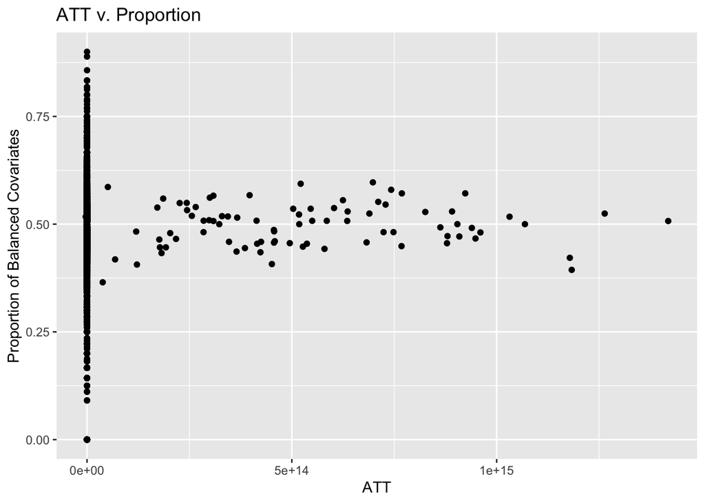

```r
# Remove post-treatment covariates

dt.pre <- dt[,-c(1, 123:180)]
dt.pre <- dt.pre[complete.cases(dt.pre),]

# Randomly select features

# num <- sample(1:120, 1)
# var <- sample(names, num, replace = F)

# Simulate random selection of features 10k+ times

models <- vector("list", 10000)
att <- vector("list", 10000)
prop_balance_covar <- vector("list", 10000)
mean_balance_improvement <- vector("list", 10000)

for (i in 1:10000) {

  names <- names(dt.pre[,c(2:121)])
  num <- sample(1:120, 1)
  var <- sample(x = names, size = num, replace = F)
  formula <- as.formula(paste(paste("college ~ student_Gen +", paste(var, collapse = " + "))))

  # Fit p-score models and save ATTs, proportion of balanced covariates, and mean percent balance improvement
  model_ps <- matchit(formula = formula,
                      data = dt.pre,
                      method = "nearest",
                      link = "logit",
                      discard = "control",
                      replace = FALSE,
                      ratio = 2,
                      estimand = "ATT")

  models[[i]] <- model_ps

  dt.md <- match.data(model_ps)

  names <- names(model_ps$model$coefficients)
  names <- names[-1]
  dt.md <- dt.md %>%
    select(college, names, distance, weights, subclass)


  # ATT
  glm <- glm(formula,
             family = binomial(link = "logit"),
             data = dt.md,
             weights = weights)

  dt.att <- as.data.frame(glm$coefficients)

  att[[i]] <- dt.att[2,1]

  # Proportion of balanced covariates
  prop_balance_covar[[i]] <- summary(model_ps) %>%
    pluck("sum.matched") %>%
    as.data.frame() %>%
    rownames_to_column(var = "variables") %>%
    rename(prop_balance_covar = "Std. Pair Dist.") %>%
    select(variables, prop_balance_covar) %>%
    summarize(prop_balance_covar = sum(prop_balance_covar > .9 & prop_balance_covar < 1.1) / length(prop_balance_covar))

  # Mean percent balance improvement
  mean_balance_improvement[[i]] <- summary(model_ps) %>%
    pluck("sum.all") %>%
    as.data.frame() %>%
    rownames_to_column(var = "variables") %>%
    rename(mean_diff = "Std. Mean Diff.") %>%
    select(variables, mean_diff) %>%
    summarize(mean_balance_improvement = mean(mean_diff, na.rm = T))

}

# Plot ATT v. proportion

att <- unlist(att)
prop_balance_covar <- unlist(prop_balance_covar)
dt.plot <- data.frame(att, prop_balance_covar)

plot <- ggplot(data = dt.plot,
               aes(x = att,
                   y = prop_balance_covar)) +
  geom_point() +
  labs(title = "ATT v. Proportion",
       x = "ATT",
       y = "Proportion of Balanced Covariates")
plot
```

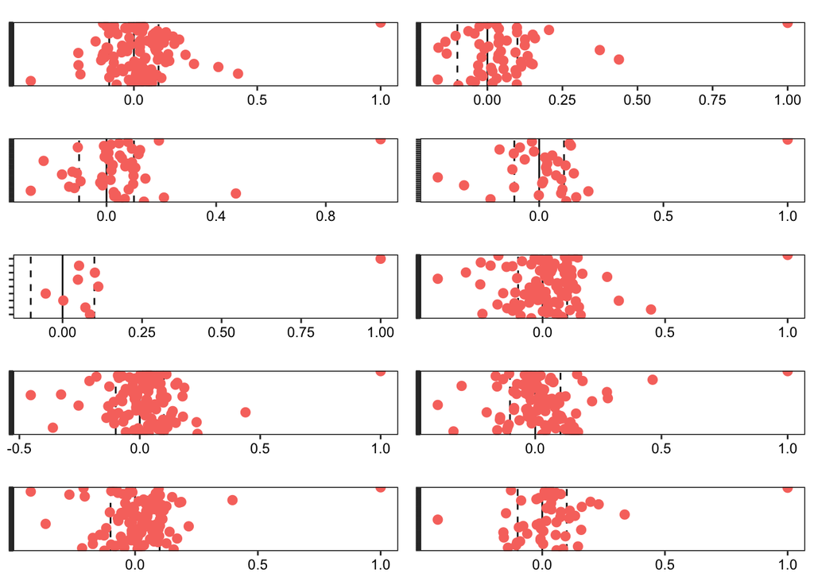

```r
# 10 random covariate balance plots (hint try gridExtra)
# Note: ggplot objects are finnicky so ask for help if you're struggling to automatically create them; consider using functions!
plots <- list()
names <- list()

for (i in 1:10) {

  mod <- sample(models, 1, replace = F)

  name <- names(mod[[1]]$model$coefficients)
  name <- name[-1]
  names[[i]] <- name

  dt.model_ps <- match.data(mod[[1]])

  dt.model_ps <- dt.model_ps %>%
    select(name)

  love <- love.plot(x = dt.model_ps,
                    treat = dt.model_ps$student_Gen,
                    pscore = dt.model_ps$distance,
                    thresholds = .1,
                    stars = "std",
                    show.legend = F,
                    title = NULL,
                    themes = theme(legend.position = "none",
                                   axis.title.x = element_blank(),
                                   axis.text.y = element_blank()))

  plots[[i]] <- love


}

love.grid <- grid.arrange(plots[[1]], plots[[2]], plots[[3]], plots[[4]], plots[[5]], plots[[6]], plots[[7]], plots[[8]], plots[[9]], plots[[10]],
                          nrow = 5)
```

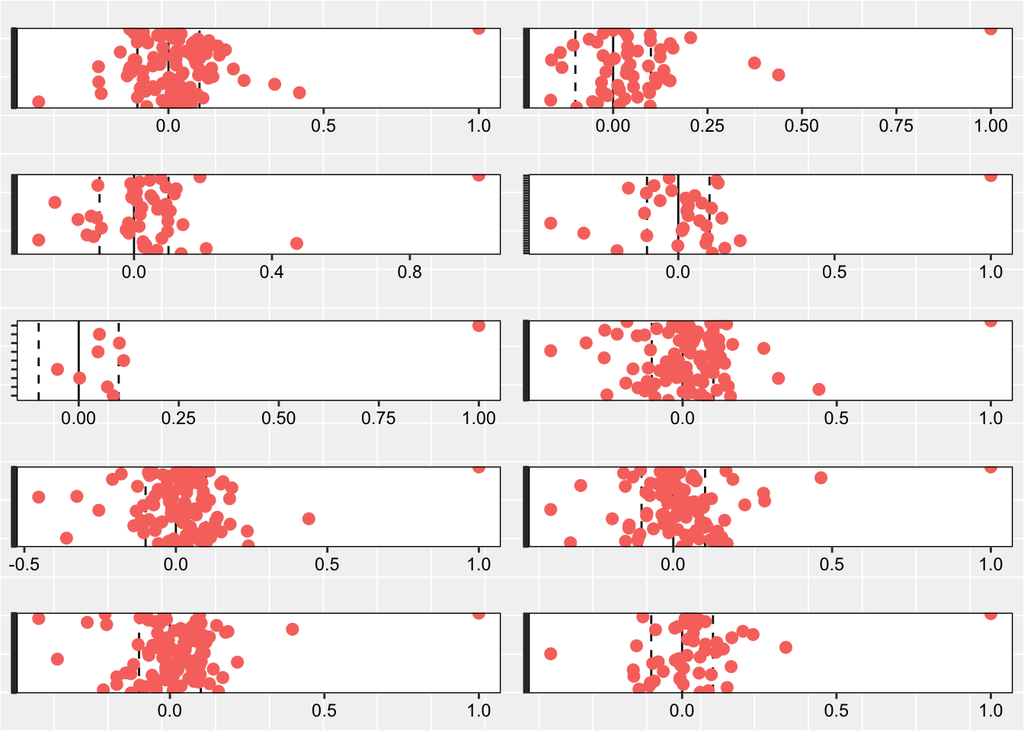

```r
plot(love.grid)
```

# Matching Algorithm of Your Choice

## Simulate Alternative Model

Henderson/Chatfield propose using genetic matching to learn the best weights for Mahalanobis distance matching. Choose a matching algorithm other than the propensity score (you may use genetic matching if you wish, but it is also fine to use the greedy or optimal algorithms we covered in lab instead). Repeat the same steps as specified in Section 4.2 and answer the following questions:

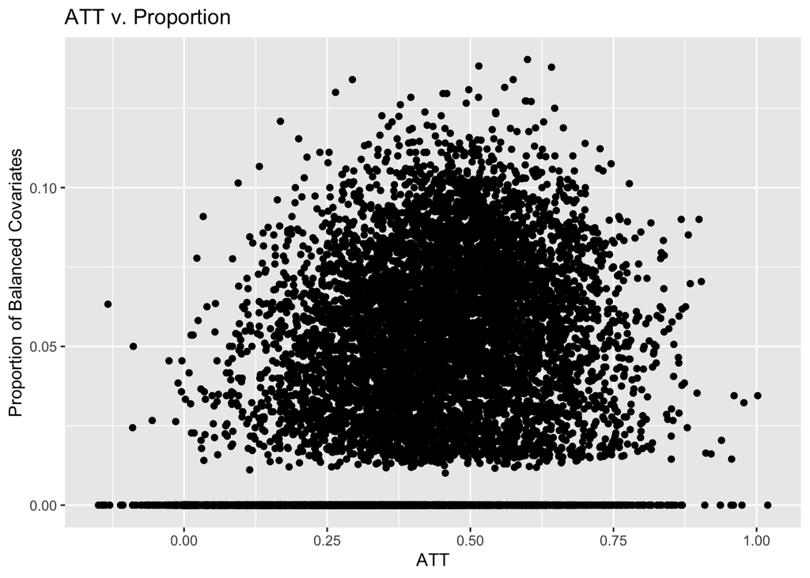

```r
# Remove post-treatment covariates

dt.pre <- dt[,-c(1, 123:180)]
dt.pre <- dt.pre[complete.cases(dt.pre),]

# Randomly select features

# num <- sample(1:120, 1)
# var <- sample(names, num, replace = F)

# Simulate random selection of features 10k+ times

models2 <- vector("list", 10000)
att2 <- vector("list", 10000)
prop_balance_covar2 <- vector("list", 10000)
mean_balance_improvement2 <- vector("list", 10000)

for (i in 1:10000) {

  names <- names(dt.pre[,c(2:121)])
  num <- sample(1:120, 1)
  var <- sample(x = names, size = num, replace = F)
  formula <- as.formula(paste(paste("college ~ student_Gen +", paste(var, collapse = " + "))))

  # Fit p-score models and save ATTs, proportion of balanced covariates, and mean percent balance improvement
  model_ps <- matchit(formula = formula,
                    data = dt.pre,
                    method = "optimal",
                    distance = "mahalanobis",
                    replace = FALSE,
                    estimand = "ATT")

  models2[[i]] <- model_ps

  dt.md <- match.data(model_ps)

  names <- names(model_ps$X)
  dt.md <- dt.md %>%
    select(college, names, weights, subclass)


  # ATT
  glm <- glm(formula,
             family = binomial(link = "logit"),
             data = dt.md,
             weights = weights)

  dt.att <- as.data.frame(glm$coefficients)

  att2[[i]] <- dt.att[2,1]

  # Proportion of balanced covariates
  prop_balance_covar2[[i]] <- summary(model_ps) %>%
    pluck("sum.matched") %>%
    as.data.frame() %>%
    rownames_to_column(var = "variables") %>%
    rename(prop_balance_covar = "Std. Pair Dist.") %>%
    select(variables, prop_balance_covar) %>%
    summarize(prop_balance_covar = sum(prop_balance_covar > .9 & prop_balance_covar < 1.1) / length(prop_balance_covar))

  # Mean percent balance improvement
  mean_balance_improvement2[[i]] <- summary(model_ps) %>%
    pluck("sum.all") %>%
    as.data.frame() %>%
    rownames_to_column(var = "variables") %>%
    rename(mean_diff = "Std. Mean Diff.") %>%
    select(variables, mean_diff) %>%
    summarize(mean_balance_improvement = mean(mean_diff, na.rm = T))

}

# Plot ATT v. proportion

att2 <- unlist(att2)
prop_balance_covar2 <- unlist(prop_balance_covar2)
dt.plot <- data.frame(att2, prop_balance_covar2)

plot <- ggplot(data = dt.plot,
               aes(x = att2,
                   y = prop_balance_covar2)) +
  geom_point() +
  labs(title = "ATT v. Proportion",
       x = "ATT",
       y = "Proportion of Balanced Covariates")
plot
```

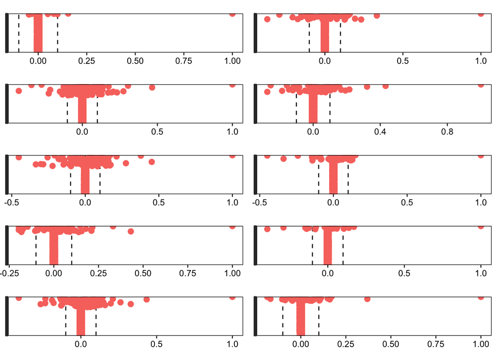

```r
# 10 random covariate balance plots (hint try gridExtra)
# Note: ggplot objects are finnicky so ask for help if you're struggling to automatically create them; consider using functions!
plots2 <- list()
names2 <- list()

for (i in 1:10) {

  mod <- sample(models, 1, replace = F)

  name <- names(mod[[1]]$X)
  names2[[i]] <- name

  dt.model_ps <- match.data(mod[[1]])

  dt.model_ps <- dt.model_ps %>%
    select(college, name, weights, subclass)

  love <- love.plot(x = dt.model_ps,
                    treat = dt.model_ps$student_Gen,
                    pscore = dt.model_ps$weights,
                    thresholds = .1,
                    stars = "std",
                    show.legend = F,
                    title = NULL,
                    themes = theme(legend.position = "none",
                                   axis.title.x = element_blank(),
                                   axis.text.y = element_blank()))

  plots2[[i]] <- love

}

love.grid2 <- grid.arrange(plots2[[1]], plots2[[2]], plots2[[3]], plots2[[4]], plots2[[5]], plots2[[6]], plots2[[7]], plots2[[8]], plots2[[9]], plots2[[10]],
                          nrow = 5)
```

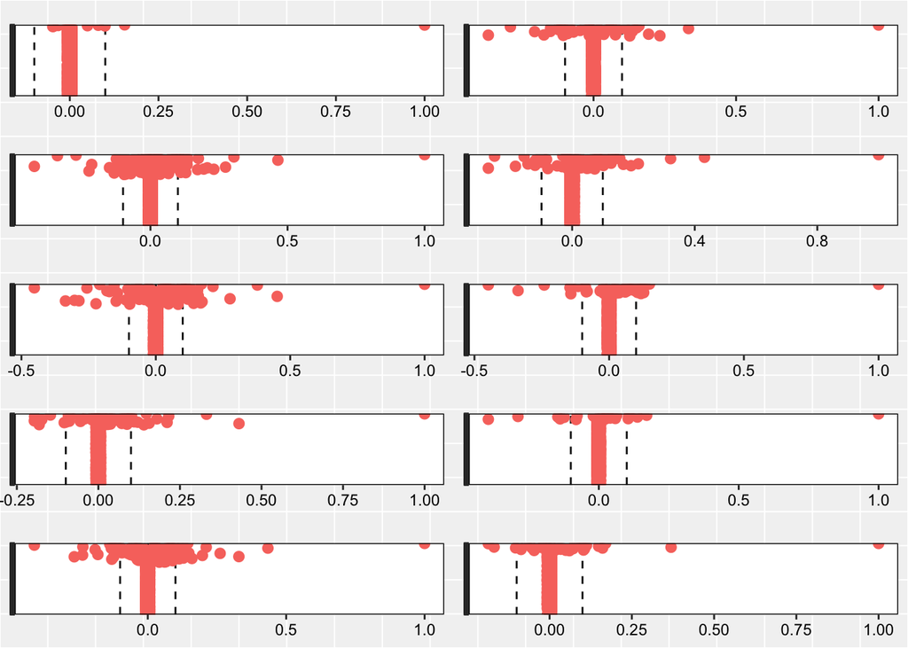

```r
plot(love.grid2)
```

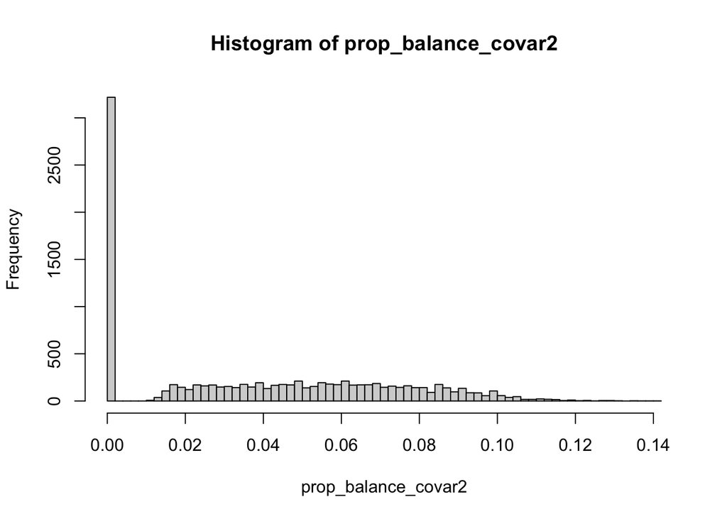

```r
# Visualization for distributions of percent improvement
hist(prop_balance_covar2,
     breaks = 100)
abline(v = dt.model_ps_bal,
       col = "blue")
abline(v = mean(prop_balance_covar),
       col = "red")
```

```r
print(sum(prop_balance_covar > 0.3333333) / 10000)
```

```
## [1] 0.9616
```